# Supervised Learning - Foundations Project: ReCell

[figure not shown]

## Used Device Price Prediction

## Problem Statement

### Business Context

Buying and selling used phones and tablets used to be something that happened on a handful of online marketplace sites. But the used and refurbished device market has grown considerably over the past decade, and a new IDC (International Data Corporation) forecast predicts that the used phone market would be worth \$52.7bn by 2023 with a compound annual growth rate (CAGR) of 13.6% from 2018 to 2023. This growth can be attributed to an uptick in demand for used phones and tablets that offer considerable savings compared with new models.

Refurbished and used devices continue to provide cost-effective alternatives to both consumers and businesses that are looking to save money when purchasing one. There are plenty of other benefits associated with the used device market. Used and refurbished devices can be sold with warranties and can also be insured with proof of purchase. Third-party vendors/platforms, such as Verizon, Amazon, etc., provide attractive offers to customers for refurbished devices. Maximizing the longevity of devices through second-hand trade also reduces their environmental impact and helps in recycling and reducing waste. The impact of the COVID-19 outbreak may further boost this segment as consumers cut back on discretionary spending and buy phones and tablets only for immediate needs.

### Objective

The rising potential of this comparatively under-the-radar market fuels **the need for an ML-based solution to develop a dynamic pricing strategy for used and refurbished devices.** ReCell, a startup aiming to tap the potential in this market, has hired you as a data scientist. They want you to analyze the data provided and **build a linear regression model** to **predict** the price of a used phone/tablet and identify factors that significantly influence it.

### Data Description

The data contains the different attributes of used/refurbished phones and tablets. The data was collected in the year 2021. The detailed data dictionary is given below.

- brand_name: Name of manufacturing brand
- os: OS on which the device runs
- screen_size: Size of the screen in cm
- 4g: Whether 4G is available or not
- 5g: Whether 5G is available or not
- main_camera_mp: Resolution of the rear camera in megapixels
- selfie_camera_mp: Resolution of the front camera in megapixels
- int_memory: Amount of internal memory (ROM) in GB
- ram: Amount of RAM in GB
- battery: Energy capacity of the device battery in mAh
- weight: Weight of the device in grams
- release_year: Year when the device model was released
- days_used: Number of days the used/refurbished device has been used
- normalized_new_price: Normalized price of a new device of the same model in euros
- normalized_used_price: Normalized price of the used/refurbished device in euros

## Importing necessary libraries

```python
# this will help in making the Python code more structured automatically (good coding practice)
%load_ext jupyter_black

# Libraries to help with reading and manipulating data
import numpy as np
import pandas as pd

# Libraries to help with data visualization
import matplotlib.pyplot as plt
import seaborn as sns

sns.set()

# split the data into train and test
from sklearn.model_selection import train_test_split

# to build linear regression_model
from sklearn.linear_model import LinearRegression

# to check model performance
from sklearn.metrics import mean_absolute_error, mean_squared_error, r2_score

# to build linear regression_model using statsmodels
import statsmodels.api as sm

# to compute VIF
from statsmodels.stats.outliers_influence import variance_inflation_factor
```

## Loading the dataset

```python
# loading data
data = pd.read_csv(
    "/Users/teslahsu/Desktop/GL/Project 3: Supervised Learning: Recall/used_device_data.csv"
)
# Read the data
```

## Data Overview

The initial steps to get an overview of any dataset is to:

- observe the first few rows of the dataset, to check whether the dataset has been loaded properly or not
- get information about the number of rows and columns in the dataset
- find out the data types of the columns to ensure that data is stored in the preferred format and the value of each property is as expected.
- check the statistical summary of the dataset to get an overview of the numerical columns of the data

### Displaying the first few rows of the dataset

```python
data.head()
```

|  | brand_name | os | screen_size | 4g | 5g | main_camera_mp | selfie_camera_mp | int_memory | ram | battery | weight | release_year | days_used | normalized_used_price | normalized_new_price |
| --- | --- | --- | --- | --- | --- | --- | --- | --- | --- | --- | --- | --- | --- | --- | --- |
| 0 | Honor | Android | 14.50 | yes | no | 13.0 | 5.0 | 64.0 | 3.0 | 3020.0 | 146.0 | 2020 | 127 | 4.307572 | 4.715100 |
| 1 | Honor | Android | 17.30 | yes | yes | 13.0 | 16.0 | 128.0 | 8.0 | 4300.0 | 213.0 | 2020 | 325 | 5.162097 | 5.519018 |
| 2 | Honor | Android | 16.69 | yes | yes | 13.0 | 8.0 | 128.0 | 8.0 | 4200.0 | 213.0 | 2020 | 162 | 5.111084 | 5.884631 |
| 3 | Honor | Android | 25.50 | yes | yes | 13.0 | 8.0 | 64.0 | 6.0 | 7250.0 | 480.0 | 2020 | 345 | 5.135387 | 5.630961 |
| 4 | Honor | Android | 15.32 | yes | no | 13.0 | 8.0 | 64.0 | 3.0 | 5000.0 | 185.0 | 2020 | 293 | 4.389995 | 4.947837 |

- A high percentage of devices seem to be running on Android.
- There are devices that have been used for nearly a year available for sale

### Checking the shape of the dataset

```python
data.shape  ## Code to get the shape of data
```

```
(3454, 15)
```

- There are 3454 rows and 15 columns in the data

### Checking the data types of the columns for the dataset

```python
data.info()
```

```
<class 'pandas.core.frame.DataFrame'>
RangeIndex: 3454 entries, 0 to 3453
Data columns (total 15 columns):
 #   Column                 Non-Null Count  Dtype
---  ------                 --------------  -----
 0   brand_name             3454 non-null   object
 1   os                     3454 non-null   object
 2   screen_size            3454 non-null   float64
 3   4g                     3454 non-null   object
 4   5g                     3454 non-null   object
 5   main_camera_mp         3275 non-null   float64
 6   selfie_camera_mp       3452 non-null   float64
 7   int_memory             3450 non-null   float64
 8   ram                    3450 non-null   float64
 9   battery                3448 non-null   float64
 10  weight                 3447 non-null   float64
 11  release_year           3454 non-null   int64
 12  days_used              3454 non-null   int64
 13  normalized_used_price  3454 non-null   float64
 14  normalized_new_price   3454 non-null   float64
dtypes: float64(9), int64(2), object(4)
memory usage: 404.9+ KB
```

- There are 11 numeric (float and int type) and 4 string (object type) columns in the data
- The target variable is the normalized price of a used device, which is of float type

### Statistical summary of the dataset

```python
data.describe(include="all").T
# Code to print the statistical summary of the data
```

|  | count | unique | top | freq | mean | std | min | 25% | 50% | 75% | max |
| --- | --- | --- | --- | --- | --- | --- | --- | --- | --- | --- | --- |
| brand_name | 3454 | 34 | Others | 502 | NaN | NaN | NaN | NaN | NaN | NaN | NaN |
| os | 3454 | 4 | Android | 3214 | NaN | NaN | NaN | NaN | NaN | NaN | NaN |
| screen_size | 3454.0 | NaN | NaN | NaN | 13.713115 | 3.80528 | 5.08 | 12.7 | 12.83 | 15.34 | 30.71 |
| 4g | 3454 | 2 | yes | 2335 | NaN | NaN | NaN | NaN | NaN | NaN | NaN |
| 5g | 3454 | 2 | no | 3302 | NaN | NaN | NaN | NaN | NaN | NaN | NaN |
| main_camera_mp | 3275.0 | NaN | NaN | NaN | 9.460208 | 4.815461 | 0.08 | 5.0 | 8.0 | 13.0 | 48.0 |
| selfie_camera_mp | 3452.0 | NaN | NaN | NaN | 6.554229 | 6.970372 | 0.0 | 2.0 | 5.0 | 8.0 | 32.0 |
| int_memory | 3450.0 | NaN | NaN | NaN | 54.573099 | 84.972371 | 0.01 | 16.0 | 32.0 | 64.0 | 1024.0 |
| ram | 3450.0 | NaN | NaN | NaN | 4.036122 | 1.365105 | 0.02 | 4.0 | 4.0 | 4.0 | 12.0 |
| battery | 3448.0 | NaN | NaN | NaN | 3133.402697 | 1299.682844 | 500.0 | 2100.0 | 3000.0 | 4000.0 | 9720.0 |
| weight | 3447.0 | NaN | NaN | NaN | 182.751871 | 88.413228 | 69.0 | 142.0 | 160.0 | 185.0 | 855.0 |
| release_year | 3454.0 | NaN | NaN | NaN | 2015.965258 | 2.298455 | 2013.0 | 2014.0 | 2015.5 | 2018.0 | 2020.0 |
| days_used | 3454.0 | NaN | NaN | NaN | 674.869716 | 248.580166 | 91.0 | 533.5 | 690.5 | 868.75 | 1094.0 |
| normalized_used_price | 3454.0 | NaN | NaN | NaN | 4.364712 | 0.588914 | 1.536867 | 4.033931 | 4.405133 | 4.7557 | 6.619433 |
| normalized_new_price | 3454.0 | NaN | NaN | NaN | 5.233107 | 0.683637 | 2.901422 | 4.790342 | 5.245892 | 5.673718 | 7.847841 |

- There are 33 brands in the data and a category Others too.
- Android is the most common OS for the used devices.
- The weight ranges from 69g to 855g.
- This does not seem incorrect as the data contains feature phones and tablets too.
- There are a few unusually low values for the internal memory and RAM of used devices, but those are likely due to the presence of feature phones in the data.
- The average value of the normalized price of a used device is approx. 4.4 euros.

### Checking for duplicate values

```python
data.duplicated()
# Code to check duplicate entries in the data
```

```
0       False
1       False
2       False
3       False
4       False
        ...
3449    False
3450    False
3451    False
3452    False
3453    False
Length: 3454, dtype: bool
```

```python
data.duplicated().sum()
```

```
0
```

- There are no duplicate values in the data

### Checking for missing values

```python
data.isnull().sum()
# Code to check missing entries in the data
```

```
brand_name                 0
os                         0
screen_size                0
4g                         0
5g                         0
main_camera_mp           179
selfie_camera_mp           2
int_memory                 4
ram                        4
battery                    6
weight                     7
release_year               0
days_used                  0
normalized_used_price      0
normalized_new_price       0
dtype: int64
```

- There are missing values in many columns.

```python
# creating a copy of the data so that original data remains unchanged
df = data.copy()
```

## Exploratory Data Analysis (EDA)

### Univariate Analysis

```python
# function to plot a boxplot and a histogram along the same scale.


def histogram_boxplot(data, feature, figsize=(15, 10), kde=False, bins=None):
    """
    Boxplot and histogram combined

    data: dataframe
    feature: dataframe column
    figsize: size of figure (default (15,10))
    kde: whether to show the density curve (default False)
    bins: number of bins for histogram (default None)
    """
    f2, (ax_box2, ax_hist2) = plt.subplots(
        nrows=2,  # Number of rows of the subplot grid= 2
        sharex=True,  # x-axis will be shared among all subplots
        gridspec_kw={"height_ratios": (0.25, 0.75)},
        figsize=figsize,
    )  # creating the 2 subplots
    sns.boxplot(
        data=data, x=feature, ax=ax_box2, showmeans=True, color="violet"
    )  # boxplot will be created and a triangle will indicate the mean value of the column
    (
        sns.histplot(data=data, x=feature, kde=kde, ax=ax_hist2, bins=bins)
        if bins
        else sns.histplot(data=data, x=feature, kde=kde, ax=ax_hist2)
    )  # For histogram
    ax_hist2.axvline(
        data[feature].mean(), color="green", linestyle="--"
    )  # Add mean to the histogram
    ax_hist2.axvline(
        data[feature].median(), color="black", linestyle="-"
    )  # Add median to the histogram
```

```python
# function to create labeled barplots


def labeled_barplot(data, feature, perc=False, n=None):
    """
    Barplot with percentage at the top

    data: dataframe
    feature: dataframe column
    perc: whether to display percentages instead of count (default is False)
    n: displays the top n category levels (default is None, i.e., display all levels)
    """

    total = len(data[feature])  # length of the column
    count = data[feature].nunique()
    if n is None:
        plt.figure(figsize=(count + 2, 6))
    else:
        plt.figure(figsize=(n + 2, 6))

    plt.xticks(rotation=90, fontsize=15)
    ax = sns.countplot(
        data=data,
        x=feature,
        palette="Paired",
        order=data[feature].value_counts().index[:n],
    )

    for p in ax.patches:
        if perc == True:
            label = "{:.1f}%".format(
                100 * p.get_height() / total
            )  # percentage of each class of the category
        else:
            label = p.get_height()  # count of each level of the category

        x = p.get_x() + p.get_width() / 2  # width of the plot
        y = p.get_height()  # height of the plot

        ax.annotate(
            label,
            (x, y),
            ha="center",
            va="center",
            size=12,
            xytext=(0, 5),
            textcoords="offset points",
        )  # annotate the percentage

    plt.show()  # show the plot
```

**`normalized_used_price`**

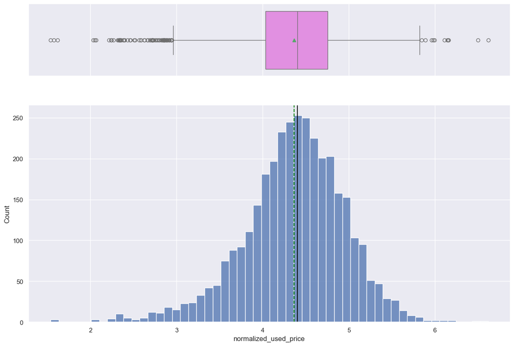

```python
histogram_boxplot(df, "normalized_used_price")
```

- The normalized used device prices are almost normally distributed.

**`normalized_new_price`**

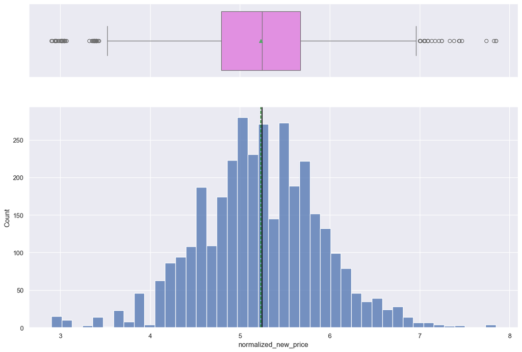

```python
histogram_boxplot(
    df, "normalized_new_price"
)
# Create histogram_boxplot for 'normalized_new_price'
```

- The normalized prices of new device models are almost normally distributed.

**`screen_size`**

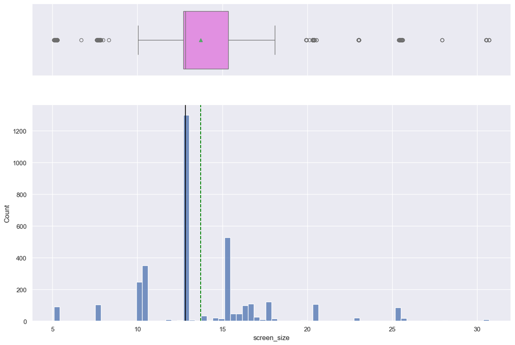

```python
histogram_boxplot(df, "screen_size")  ## Create histogram_boxplot for 'screen_size'
```

- Around 50% of the devices have a screen larger than 13cm.

**`main_camera_mp`**

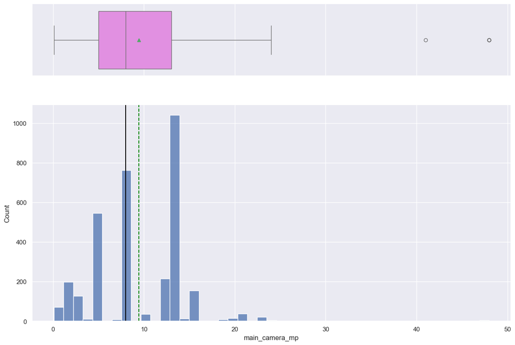

```python
histogram_boxplot(
    df, "main_camera_mp"
)
# Create histogram_boxplot for 'main_camera_mp'
```

- Few devices offer rear cameras with more than 20MP resolution.

**`selfie_camera_mp`**

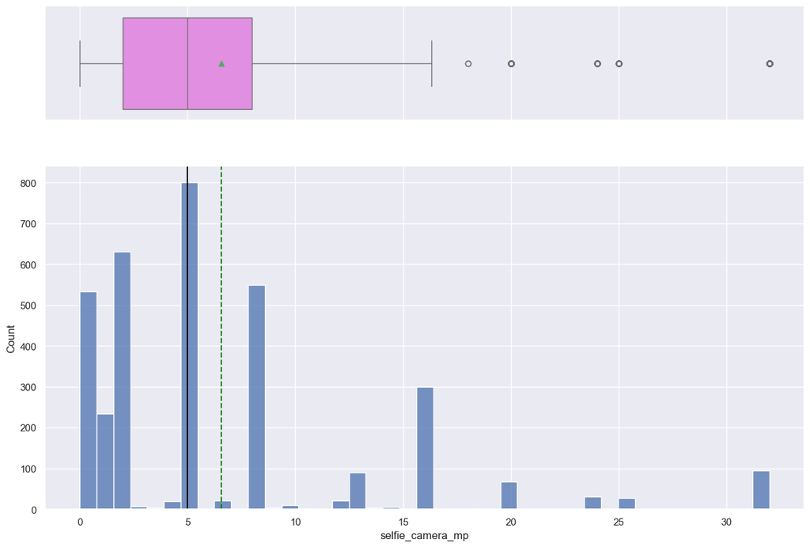

```python
histogram_boxplot(
    df, "selfie_camera_mp"
)
# Create histogram_boxplot for 'selfie_camera_mp'
```

- Some devices do not provide a front camera (most likely the feature phones), while few devices offer ones with more than 16MP resolution.

**`int_memory`**

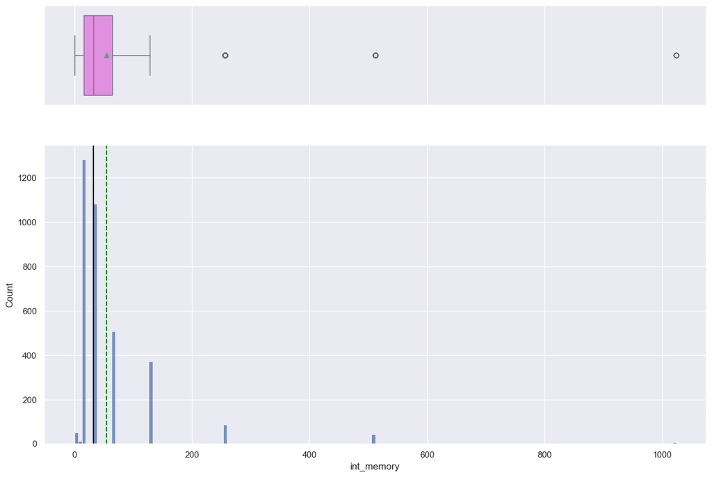

```python
histogram_boxplot(df, "int_memory")
# Create histogram_boxplot for 'int_memory'
```

- Few devices offer more than 256GB internal memory.

**`ram`**

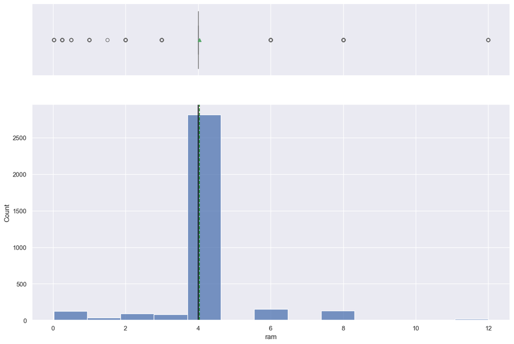

```python
histogram_boxplot(df, "ram")
# Create histogram_boxplot for 'ram'
```

- Most of the devices offer 4GB RAM and very few offer greater than 8GB RAM.

**`weight`**

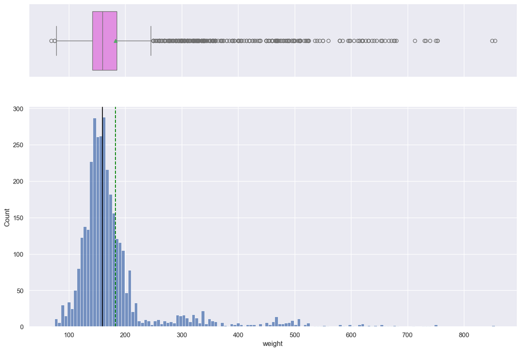

```python
histogram_boxplot(df, "weight")  ## Create histogram_boxplot for 'weight'
```

- The distribution of weight is right-skewed and has many upper outliers.

**`battery`**

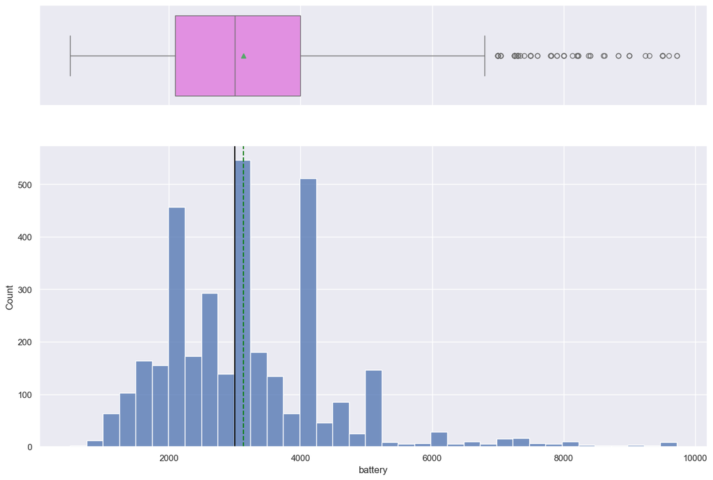

```python
histogram_boxplot(df, "battery")  ## Create histogram_boxplot for 'battery'
```

- The distribution of energy capacity of battery is close to normally distributed with a few upper outliers.

**`days_used`**

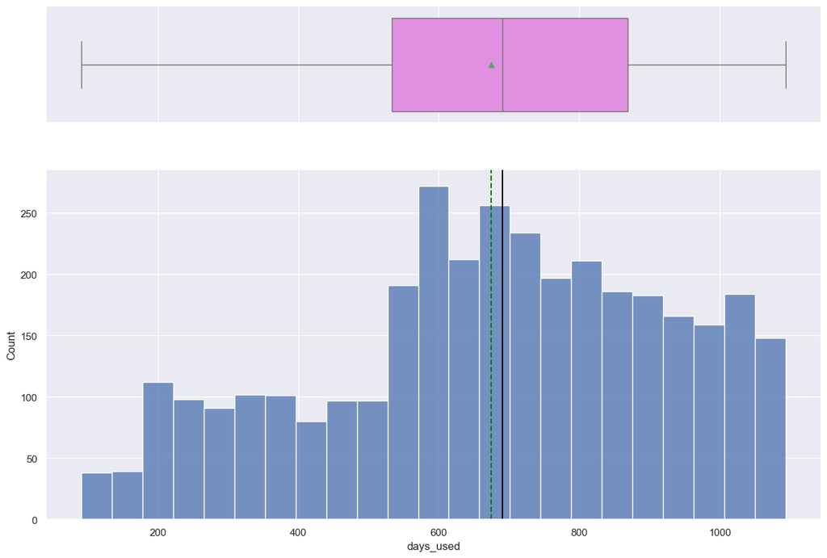

```python
histogram_boxplot(df, "days_used")  ## Create histogram_boxplot for 'days_used'
```

- Around 50% of the devices in the data have been used for more than 700 days.

**`brand_name`**

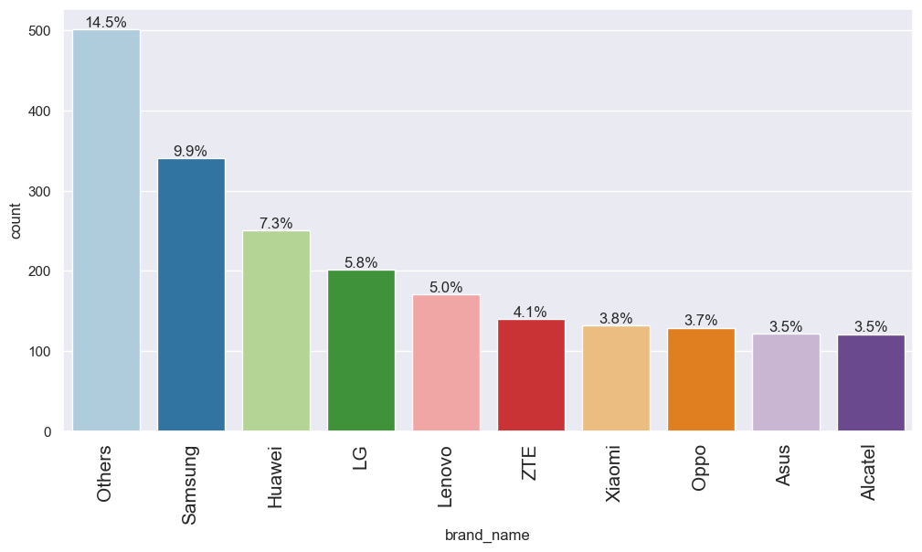

```python
labeled_barplot(df, "brand_name", perc=True, n=10)
```

#### Observations

- Samsung has the most number of devices in the data, followed by Huawei and LG.
- 14.5% of the devices in the data are from brands other than the listed ones.

**`os`**

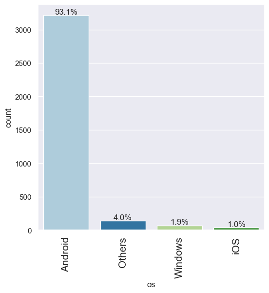

```python
labeled_barplot(df, "os", perc=True)
# Create labeled_barplot for 'os'
```

- Android devices dominate ~93% of the used device market.

**`4g`**

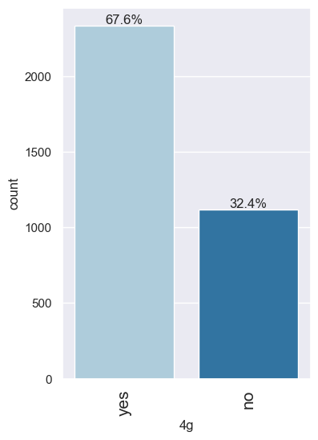

```python
labeled_barplot(df, "4g", perc=True)
# Create labeled_barplot for '4g'
```

- Nearly two-thirds of the devices in this data have 4G available.

**`5g`**

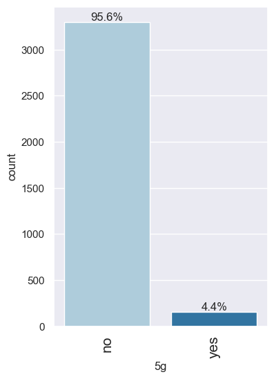

```python
labeled_barplot(df, "5g", perc=True)
# Create labeled_barplot for '5g'
```

- Only a handful of devices in this data provide 5G network.

**`release_year`**

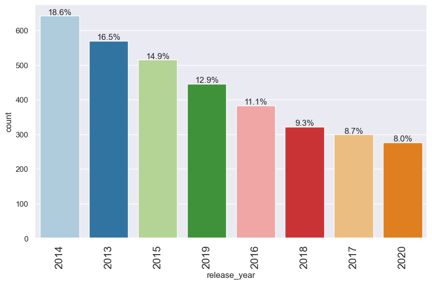

```python
labeled_barplot(df, "release_year", perc=True)
# Create labeled_barplot for 'release_year'
```

- Around 50% of the devices in the data were originally released in 2015 or before.

### Bivariate Analysis

**Correlation Check**

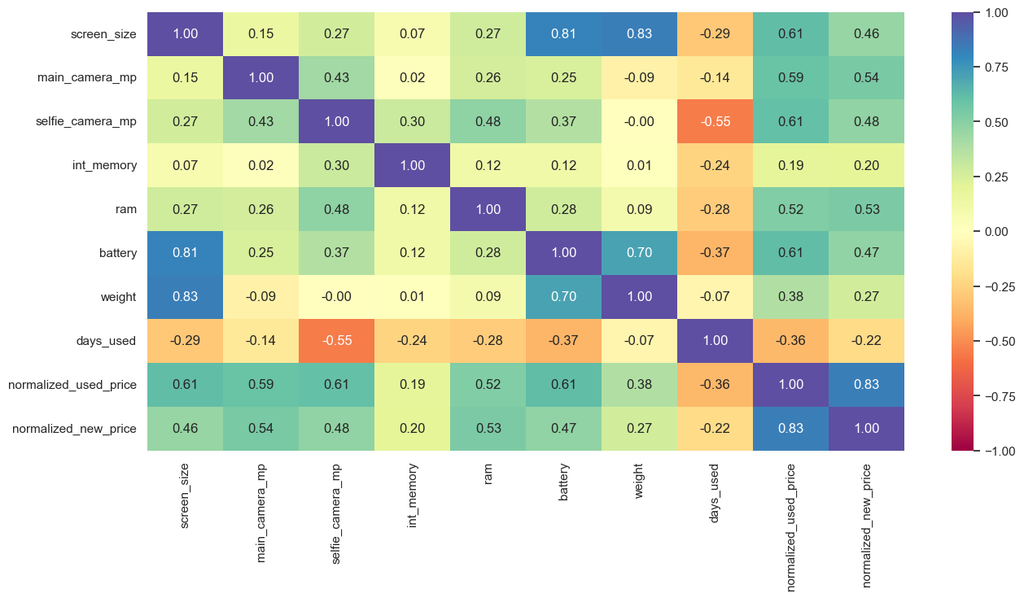

```python
cols_list = df.select_dtypes(include=np.number).columns.tolist()
# dropping release_year as it is a temporal variable
cols_list.remove("release_year")

plt.figure(figsize=(15, 7))
sns.heatmap(
    df[cols_list].corr(), annot=True, vmin=-1, vmax=1, fmt=".2f", cmap="Spectral"
)
plt.show()
```

### Observations

- The normalized used device price is highly correlated with the normalized price of a new device model.
- This makes sense as the price of a new model is likely to affect the used device price.
- The normalized used device price is also moderately correlated with the resolution of the cameras provided, the size of the screen, and the battery capacity.
- Weight, screen size, and battery capacity of a device show a good amount of correlation.
- This makes sense as larger battery capacity requires bigger space, thereby increasing screen size and weight.
- The number of days a device is used is negatively correlated with the resolution of its front camera.
- This makes sense as older devices did not offer as powerful front cameras as the recent ones.

**The amount of RAM is important for the smooth functioning of a device. Let's see how the amount of RAM varies across brands.**

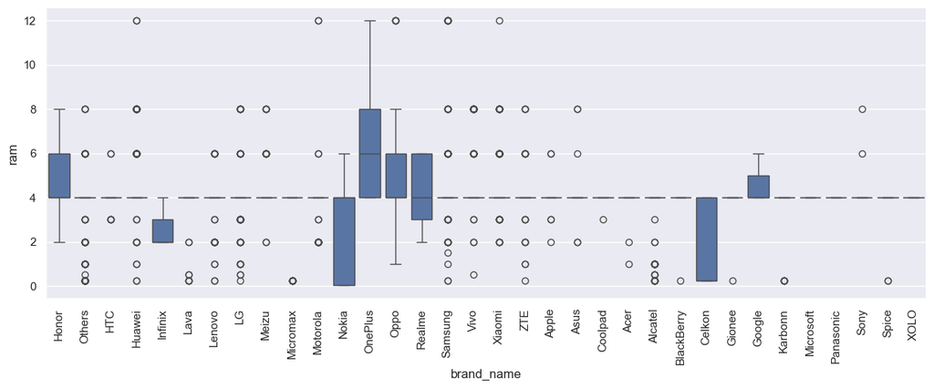

```python
plt.figure(figsize=(15, 5))
sns.boxplot(data=df, x="brand_name", y="ram")
plt.xticks(rotation=90)
plt.show()
```

### Observations

- 50% of the devices offered by most of the companies have 4GB of RAM.
- 50% of OnePlus devices have 6GB or more RAM, indicating that OnePlus devices offer more RAM in general.

**People who travel frequently require devices with large batteries to run through the day. But large battery often increases weight, making it feel uncomfortable in the hands. Let's create a new dataframe of only those devices which offer a large battery and analyze.**

```python
df_large_battery = df[df.battery > 4500]
df_large_battery.shape
```

```
(341, 15)
```

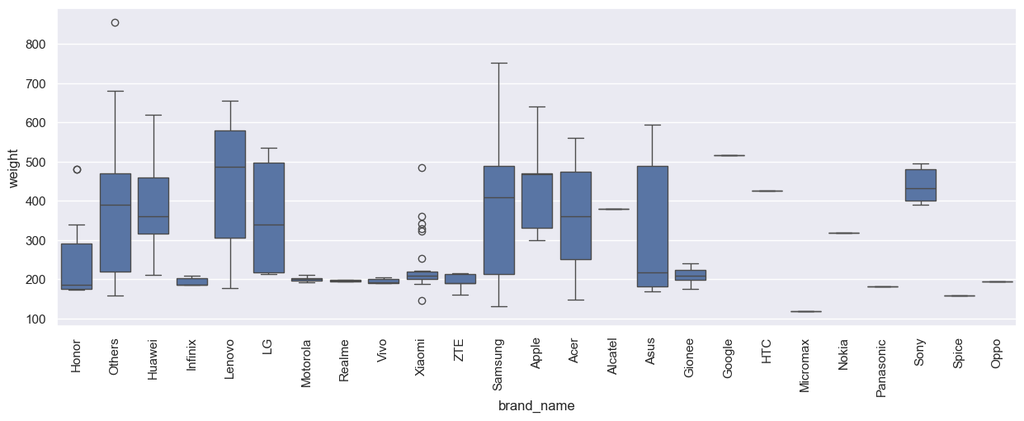

```python
plt.figure(figsize=(15, 5))
sns.boxplot(data=df_large_battery, x="brand_name", y="weight")
# Create a boxplot for 'brand_name' and 'weight'
plt.xticks(rotation=90)
plt.show()
```

### Observations

- A lot of brands offer devices which are not very heavy but have a large battery capacity.
- Some devices offered by brands like Vivo, Realme, Motorola, etc. weigh just about 200g but offer great batteries.
- Some devices offered by brands like Huawei, Apple, Sony, etc. offer great batteries but are heavier.

**People who buy phones and tablets primarily for entertainment purposes prefer a large screen as they offer a better viewing experience. Let's create a new dataframe of only those devices which are suitable for such people and analyze.**

```python
df_large_screen = df[df.screen_size > 6 * 2.54]
df_large_screen.shape
```

```
(1099, 15)
```

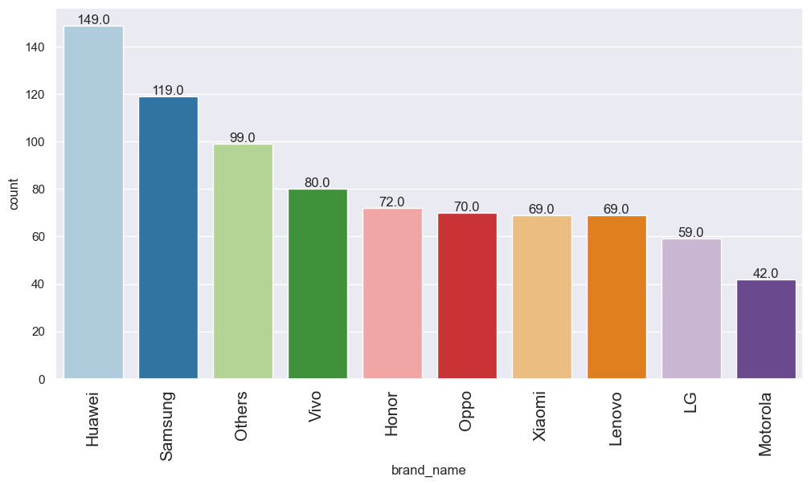

```python
labeled_barplot(df_large_screen, "brand_name", n=10)
# Create labeled_barplot for 'brand_name' in large screen dataframe
```

### Observations

- Huawei and Samsung offer a lot of devices suitable for customers buying phones and tablets for entertainment purposes.

**Everyone likes a good camera to capture their favorite moments with loved ones. Some customers specifically look for good front cameras to click cool selfies. Let's create a new dataframe of only those devices which are suitable for this customer segment and analyze.**

```python
df_selfie_camera = df[df.selfie_camera_mp > 8]
df_selfie_camera.shape
```

```
(655, 15)
```

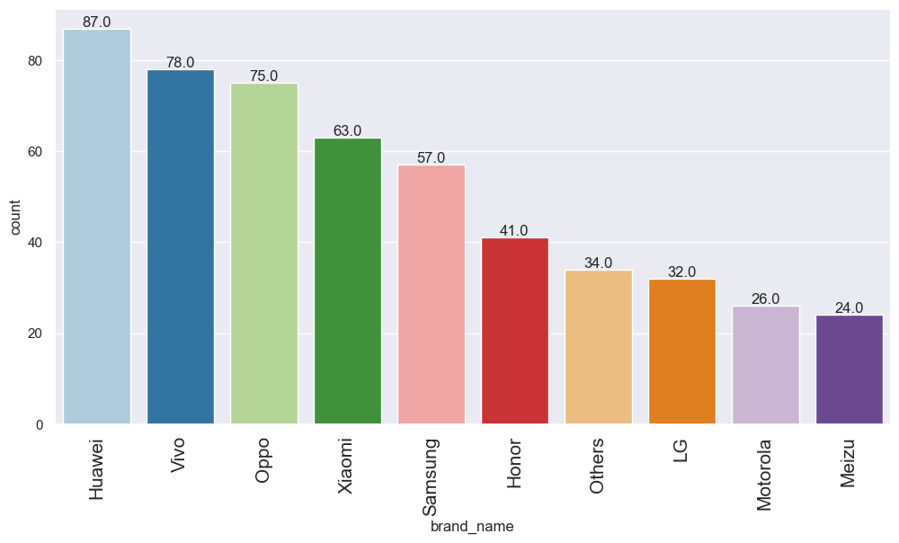

```python
labeled_barplot(df_selfie_camera, "brand_name", n=10)
# Create labeled_barplot for 'brand_name' in high selfie camera dataframe
```

### Observations

- Huawei is the go-to brand for this customer segment as they offer many devices with powerful front cameras.
- Oppo and Vivo also offer a lot of devices suitable for this customer segment.

**Let's do a similar analysis for rear cameras.**

- Rear cameras generally have a better resolution than front cameras, so we set the threshold higher for them at 16MP.

```python
df_main_camera = df[df.main_camera_mp > 16]
df_main_camera.shape
```

```
(94, 15)
```

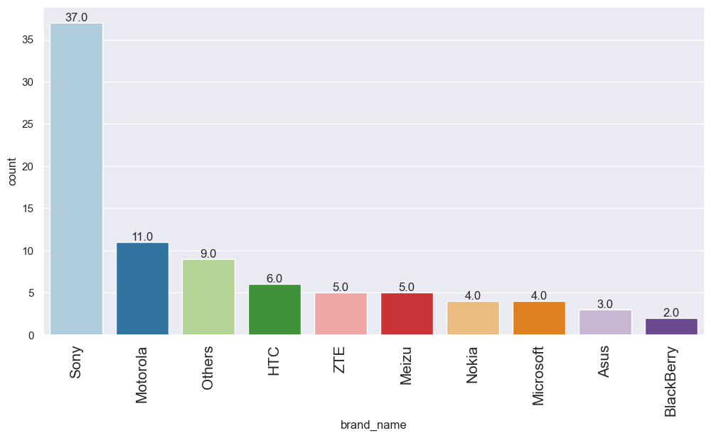

```python
labeled_barplot(df_main_camera, "brand_name", n=10)
# Create labeled_barplot for 'brand_name' in high main camera dataframe
```

### Observations

- Sony is the go-to brand for great rear cameras as they offer many devices under this criteria.

**Let's see how the price of used devices varies across the years.**

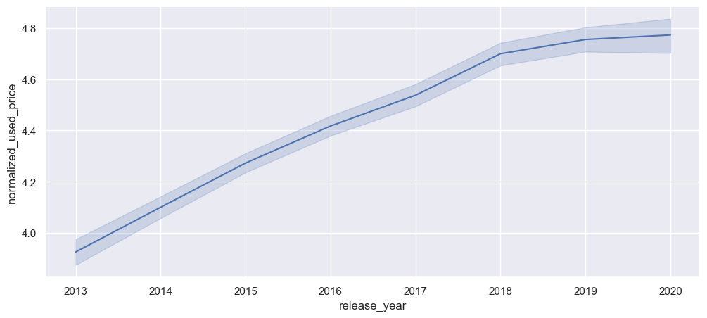

```python
plt.figure(figsize=(12, 5))
sns.lineplot(data=data, x="release_year", y="normalized_used_price")
plt.show()
```

- The price of used devices has increased over the years.

**Let's check how the prices vary for used phones and tablets offering 4G and 5G networks.**

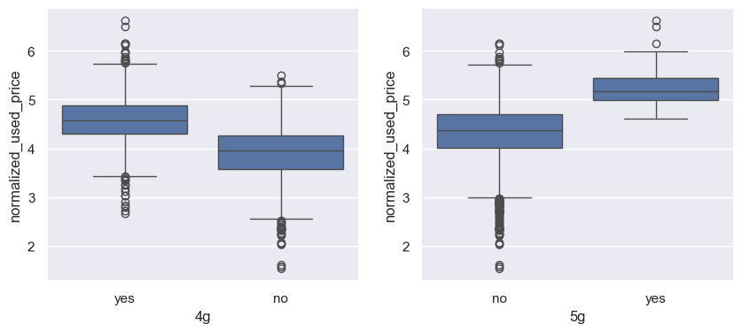

```python
plt.figure(figsize=(10, 4))

plt.subplot(121)
sns.boxplot(data=df, x="4g", y="normalized_used_price")

plt.subplot(122)
sns.boxplot(data=df, x="5g", y="normalized_used_price")

plt.show()
```

### Observations

- As expected, used devices offering 4G and 5G networks are generally priced higher than the ones without 4G and 5G networks.

## Data Preprocessing

### Missing Value Imputation

- We will impute the missing values in the data by the column medians grouped by `release_year` and `brand_name`.

```python
# let's create a copy of the data
df1 = df.copy()
```

```python
# checking for missing values
df1.isnull().sum()
## Check missing values in all the columns
```

```
brand_name                 0
os                         0
screen_size                0
4g                         0
5g                         0
main_camera_mp           179
selfie_camera_mp           2
int_memory                 4
ram                        4
battery                    6
weight                     7
release_year               0
days_used                  0
normalized_used_price      0
normalized_new_price       0
dtype: int64
```

```python
cols_impute = [
    "main_camera_mp",
    "selfie_camera_mp",
    "int_memory",
    "ram",
    "battery",
    "weight",
]

for col in cols_impute:
    df1[col] = df1[col].fillna(
        value=df1.groupby(["release_year", "brand_name"])[col].transform("median")
    )  ## Complete the code to impute missing values in cols_impute with median by grouping the data on release year and brand name

# checking for missing values
df1.isnull().sum()
## Check missing values after imputing the above columns
```

```
brand_name                 0
os                         0
screen_size                0
4g                         0
5g                         0
main_camera_mp           179
selfie_camera_mp           2
int_memory                 0
ram                        0
battery                    6
weight                     7
release_year               0
days_used                  0
normalized_used_price      0
normalized_new_price       0
dtype: int64
```

- We will impute the remaining missing values in the data by the column medians grouped by `brand_name`.

```python
cols_impute = [
    "main_camera_mp",
    "selfie_camera_mp",
    "battery",
    "weight",
]

for col in cols_impute:
    df1[col] = df1[col].fillna(
        value=df1.groupby(["brand_name"])[col].transform("median")
    )  ## Impute the missing values in cols_impute with median by grouping the data on brand name

# checking for missing values
df1.isnull().sum()  ## Check missing values after imputing the above columns
```

```
brand_name                0
os                        0
screen_size               0
4g                        0
5g                        0
main_camera_mp           10
selfie_camera_mp          0
int_memory                0
ram                       0
battery                   0
weight                    0
release_year              0
days_used                 0
normalized_used_price     0
normalized_new_price      0
dtype: int64
```

- We will fill the remaining missing values in the `main_camera_mp` column by the column median.

```python
df1["main_camera_mp"] = df1["main_camera_mp"].fillna(
    df1["main_camera_mp"].median
)  ## Impute the data with median

# checking for missing values
df1.isnull().sum()  ## Check missing values after imputing the above columns
```

```
brand_name               0
os                       0
screen_size              0
4g                       0
5g                       0
main_camera_mp           0
selfie_camera_mp         0
int_memory               0
ram                      0
battery                  0
weight                   0
release_year             0
days_used                0
normalized_used_price    0
normalized_new_price     0
dtype: int64
```

- All missing values have been imputed.

### Feature Engineering

- Let's create a new column `years_since_release` from the `release_year` column.
- We will consider the year of data collection, 2021, as the baseline.
- We will drop the `release_year` column.

```python
df1["years_since_release"] = 2021 - df1["release_year"]
df1.drop("release_year", axis=1, inplace=True)
df1["years_since_release"].describe()
```

```
count    3454.000000
mean        5.034742
std         2.298455
min         1.000000
25%         3.000000
50%         5.500000
75%         7.000000
max         8.000000
Name: years_since_release, dtype: float64
```

- 50% of the used devices in the data were originally released five and half years ago.

### Outlier Check

- Let's check for outliers in the data.

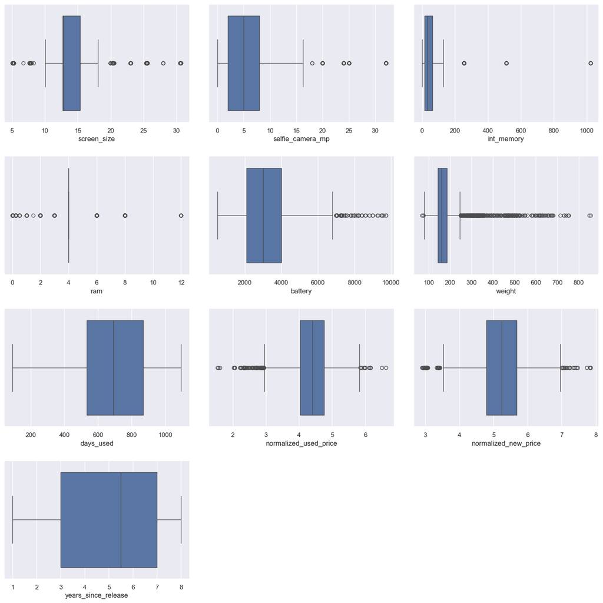

```python
# outlier detection using boxplot
num_cols = df1.select_dtypes(include=np.number).columns.tolist()

plt.figure(figsize=(15, 15))

for i, variable in enumerate(num_cols):
    plt.subplot(4, 3, i + 1)
    sns.boxplot(data=df1, x=variable)
    plt.tight_layout(pad=2)

plt.show()
```

### Observations

- There are quite a few outliers in the data
- However, we will not treat them as they are proper values

```python
# let's check the statistical summary of the data
df1.describe(include="all").T
```

|  | count | unique | top | freq | mean | std | min | 25% | 50% | 75% | max |
| --- | --- | --- | --- | --- | --- | --- | --- | --- | --- | --- | --- |
| brand_name | 3454 | 34 | Others | 502 | NaN | NaN | NaN | NaN | NaN | NaN | NaN |
| os | 3454 | 4 | Android | 3214 | NaN | NaN | NaN | NaN | NaN | NaN | NaN |
| screen_size | 3454.0 | NaN | NaN | NaN | 13.713115 | 3.80528 | 5.08 | 12.7 | 12.83 | 15.34 | 30.71 |
| 4g | 3454 | 2 | yes | 2335 | NaN | NaN | NaN | NaN | NaN | NaN | NaN |
| 5g | 3454 | 2 | no | 3302 | NaN | NaN | NaN | NaN | NaN | NaN | NaN |
| main_camera_mp | 3454.0 | 42.0 | 13.0 | 1196.0 | NaN | NaN | NaN | NaN | NaN | NaN | NaN |
| selfie_camera_mp | 3454.0 | NaN | NaN | NaN | 6.555067 | 6.96844 | 0.0 | 2.0 | 5.0 | 8.0 | 32.0 |
| int_memory | 3454.0 | NaN | NaN | NaN | 54.528474 | 84.934991 | 0.01 | 16.0 | 32.0 | 64.0 | 1024.0 |
| ram | 3454.0 | NaN | NaN | NaN | 4.03262 | 1.368598 | 0.02 | 4.0 | 4.0 | 4.0 | 12.0 |
| battery | 3454.0 | NaN | NaN | NaN | 3132.577446 | 1298.884193 | 500.0 | 2100.0 | 3000.0 | 4000.0 | 9720.0 |
| weight | 3454.0 | NaN | NaN | NaN | 182.636856 | 88.360445 | 69.0 | 142.0 | 160.0 | 185.0 | 855.0 |
| days_used | 3454.0 | NaN | NaN | NaN | 674.869716 | 248.580166 | 91.0 | 533.5 | 690.5 | 868.75 | 1094.0 |
| normalized_used_price | 3454.0 | NaN | NaN | NaN | 4.364712 | 0.588914 | 1.536867 | 4.033931 | 4.405133 | 4.7557 | 6.619433 |
| normalized_new_price | 3454.0 | NaN | NaN | NaN | 5.233107 | 0.683637 | 2.901422 | 4.790342 | 5.245892 | 5.673718 | 7.847841 |
| years_since_release | 3454.0 | NaN | NaN | NaN | 5.034742 | 2.298455 | 1.0 | 3.0 | 5.5 | 7.0 | 8.0 |

### Data Preparation for modeling

- We want to predict the normalized price of used devices
- Before we proceed to build a model, we'll have to encode categorical features
- We'll split the data into train and test to be able to evaluate the model that we build on the train data
- We will build a Linear Regression model using the train data and then check it's performance

```python
# Assuming 'df1' is your DataFrame and 'normalized_price' is the target variable
X = df1.drop("normalized_used_price", axis=1)  # Independent variables
y = df1["normalized_used_price"]  # Dependent variable

print(X.head())
print()
print(y.head())
```

```
  brand_name       os  screen_size   4g   5g main_camera_mp  selfie_camera_mp  \
0      Honor  Android        14.50  yes   no           13.0               5.0
1      Honor  Android        17.30  yes  yes           13.0              16.0
2      Honor  Android        16.69  yes  yes           13.0               8.0
3      Honor  Android        25.50  yes  yes           13.0               8.0
4      Honor  Android        15.32  yes   no           13.0               8.0

   int_memory  ram  battery  weight  days_used  normalized_new_price  \
0        64.0  3.0   3020.0   146.0        127              4.715100
1       128.0  8.0   4300.0   213.0        325              5.519018
2       128.0  8.0   4200.0   213.0        162              5.884631
3        64.0  6.0   7250.0   480.0        345              5.630961
4        64.0  3.0   5000.0   185.0        293              4.947837

   years_since_release
0                    1
1                    1
2                    1
3                    1
4                    1

0    4.307572
1    5.162097
2    5.111084
3    5.135387
4    4.389995
Name: normalized_used_price, dtype: float64
```

```python
# let's add the intercept to data
X = sm.add_constant(X)
```

```python
# creating dummy variables for categorical features
X = pd.get_dummies(
    X,
    columns=X.select_dtypes(include=["object", "category"]).columns.tolist(),
    drop_first=True,
    dtype=int,
)

X.head()
```

|  | const | screen_size | selfie_camera_mp | int_memory | ram | battery | weight | days_used | normalized_new_price | years_since_release | ... | main_camera_mp_20.1 | main_camera_mp_12.6 | main_camera_mp_16.3 | main_camera_mp_22.6 | main_camera_mp_19.0 | main_camera_mp_21.5 | main_camera_mp_21.2 | main_camera_mp_8.1 | main_camera_mp_1.2 | main_camera_mp_22.5 |
| --- | --- | --- | --- | --- | --- | --- | --- | --- | --- | --- | --- | --- | --- | --- | --- | --- | --- | --- | --- | --- | --- |
| 0 | 1.0 | 14.50 | 5.0 | 64.0 | 3.0 | 3020.0 | 146.0 | 127 | 4.715100 | 1 | ... | 0 | 0 | 0 | 0 | 0 | 0 | 0 | 0 | 0 | 0 |
| 1 | 1.0 | 17.30 | 16.0 | 128.0 | 8.0 | 4300.0 | 213.0 | 325 | 5.519018 | 1 | ... | 0 | 0 | 0 | 0 | 0 | 0 | 0 | 0 | 0 | 0 |
| 2 | 1.0 | 16.69 | 8.0 | 128.0 | 8.0 | 4200.0 | 213.0 | 162 | 5.884631 | 1 | ... | 0 | 0 | 0 | 0 | 0 | 0 | 0 | 0 | 0 | 0 |
| 3 | 1.0 | 25.50 | 8.0 | 64.0 | 6.0 | 7250.0 | 480.0 | 345 | 5.630961 | 1 | ... | 0 | 0 | 0 | 0 | 0 | 0 | 0 | 0 | 0 | 0 |
| 4 | 1.0 | 15.32 | 8.0 | 64.0 | 3.0 | 5000.0 | 185.0 | 293 | 4.947837 | 1 | ... | 0 | 0 | 0 | 0 | 0 | 0 | 0 | 0 | 0 | 0 |

5 rows × 89 columns

```python
# Splitting the data into train and test sets in a 70:30 ratio
X_train, X_test, y_train, y_test = train_test_split(X, y, test_size=0.3, random_state=1)
```

```python
print("Number of rows in train data =", x_train.shape[0])
print("Number of rows in test data =", x_test.shape[0])
```

```
Number of rows in train data = 2417
Number of rows in test data = 1037
```

## Model Building - Linear Regression

```python
# Assuming X_train and y_train are already defined and preprocessed
X_train_with_constant = sm.add_constant(X_train.astype(float))
y_train_float = y_train.astype(float)
```

```python
# Fit the OLS model
olsmodel1 = sm.OLS(y_train_float, X_train_with_constant).fit()

# Print the summary of the model
print(olsmodel1.summary())
```

```
                              OLS Regression Results
=================================================================================
Dep. Variable:     normalized_used_price   R-squared:                       0.850
Model:                               OLS   Adj. R-squared:                  0.845
Method:                    Least Squares   F-statistic:                     159.2
Date:                   Thu, 19 Jun 2025   Prob (F-statistic):               0.00
Time:                           22:47:32   Log-Likelihood:                 163.90
No. Observations:                   2417   AIC:                            -159.8
Df Residuals:                       2333   BIC:                             326.6
Df Model:                             83
Covariance Type:               nonrobust
============================================================================================================================================================================================================================================================================================================…
                                                                                                                                                                                                                                                                                         coef    std err    …
------------------------------------------------------------------------------------------------------------------------------------------------------------------------------------------------------------------------------------------------------------------------------------------------------------…
const                                                                                                                                                                                                                                                                                  1.6815      0.080    …
screen_size                                                                                                                                                                                                                                                                            0.0238      0.003    …
selfie_camera_mp                                                                                                                                                                                                                                                                       0.0137      0.001    …
int_memory                                                                                                                                                                                                                                                                             0.0002   7.09e-05    …
ram                                                                                                                                                                                                                                                                                    0.0223      0.005    …
battery                                                                                                                                                                                                                                                                            -1.753e-05   7.39e-06    …
weight                                                                                                                                                                                                                                                                                 0.0011      0.000    …
days_used                                                                                                                                                                                                                                                                           2.496e-05   3.11e-05    …
normalized_new_price                                                                                                                                                                                                                                                                   0.4146      0.013    …
years_since_release                                                                                                                                                                                                                                                                   -0.0213      0.005    …
brand_name_Alcatel                                                                                                                                                                                                                                                                     0.0093      0.047    …
brand_name_Apple                                                                                                                                                                                                                                                                      -0.1129      0.147    …
```

[output cut: 99 more lines]

### Observations

- Both the R-squared and Adjusted R squared of our model are greater than 0.8, indicating that it can explain more than 80% of the variance in the normalized price of used phones.
- This is a clear indication that we have been able to create a very good model which is not underfitting the data.
- To be able to make statistical inferences from our model, we will have to test that the linear regression assumptions are followed.

### Model Performance Check

**Let's check the performance of the model using different metrics.**

- We will be using metric functions defined in sklearn for RMSE, MAE, and $R^2$.
- We will define a function to calculate MAPE and adjusted $R^2$.
- We will create a function which will print out all the above metrics in one go.

```python
# function to compute adjusted R-squared
def adj_r2_score(predictors, targets, predictions):
    r2 = r2_score(targets, predictions)
    n = predictors.shape[0]
    k = predictors.shape[1]
    return 1 - ((1 - r2) * (n - 1) / (n - k - 1))


# function to compute MAPE
def mape_score(targets, predictions):
    return np.mean(np.abs(targets - predictions) / targets) * 100


# function to compute different metrics to check performance of a regression model
def model_performance_regression(model, predictors, target):
    """
    Function to compute different metrics to check regression model performance

    model: regressor
    predictors: independent variables
    target: dependent variable
    """

    # predicting using the independent variables
    pred = model.predict(predictors)

    r2 = r2_score(target, pred)  # to compute R-squared
    adjr2 = adj_r2_score(predictors, target, pred)  # to compute adjusted R-squared
    rmse = np.sqrt(mean_squared_error(target, pred))  # to compute RMSE
    mae = mean_absolute_error(target, pred)  # to compute MAE
    mape = mape_score(target, pred)  # to compute MAPE

    # creating a dataframe of metrics
    df_perf = pd.DataFrame(
        {
            "RMSE": rmse,
            "MAE": mae,
            "R-squared": r2,
            "Adj. R-squared": adjr2,
            "MAPE": mape,
        },
        index=[0],
    )

    return df_perf
```

```python
# checking model performance on train set (seen 70% data)
print("Training Performance\n")
olsmodel1_train_perf = model_performance_regression(olsmodel1, x_train, y_train)
olsmodel1_train_perf
```

```
Training Performance
```

|  | RMSE | MAE | R-squared | Adj. R-squared | MAPE |
| --- | --- | --- | --- | --- | --- |
| 0 | 0.226107 | 0.17736 | 0.849942 | 0.844202 | 4.247918 |

```python
# checking model performance on test set (seen 30% data)
print("Test Performance\n")
olsmodel1_test_perf = model_performance_regression(
    olsmodel1, x_test, y_test
)
# Code to check the performance on test data
olsmodel1_test_perf
```

```
Test Performance
```

|  | RMSE | MAE | R-squared | Adj. R-squared | MAPE |
| --- | --- | --- | --- | --- | --- |
| 0 | 0.239404 | 0.185272 | 0.841094 | 0.82616 | 4.495925 |

## Checking Linear Regression Assumptions

We will be checking the following Linear Regression assumptions:

1. **No Multicollinearity**
2. **Linearity of variables**
3. **Independence of error terms**
4. **Normality of error terms**
5. **No Heteroscedasticity**

### TEST FOR MULTICOLLINEARITY

- We will test for multicollinearity using VIF.
- **General Rule of thumb**:
  - If VIF is 1 then there is no correlation between the $k$th predictor and the remaining predictor variables.
  - If VIF exceeds 5 or is close to exceeding 5, we say there is moderate multicollinearity.
  - If VIF is 10 or exceeding 10, it shows signs of high multicollinearity.

Let's define a function to check VIF.

```python
# Let's define a function to check VIF.


def checking_vif(predictors):
    vif = pd.DataFrame()
    vif["feature"] = predictors.columns

    # calculating VIF for each feature
    vif["VIF"] = [
        variance_inflation_factor(predictors.values, i)
        for i in range(len(predictors.columns))
    ]
    return vif
```

```python
checking_vif(x_train)  # Code to check VIF on train data
```

|  | feature | VIF |
| --- | --- | --- |
| 0 | const | 293.713519 |
| 1 | screen_size | 8.072753 |
| 2 | selfie_camera_mp | 2.897750 |
| 3 | int_memory | 1.434004 |
| 4 | ram | 2.375248 |
| ... | ... | ... |
| 84 | main_camera_mp_21.5 | 1.033344 |
| 85 | main_camera_mp_21.2 | 1.059116 |
| 86 | main_camera_mp_8.1 | 1.137137 |
| 87 | main_camera_mp_1.2 | 1.043345 |
| 88 | main_camera_mp_22.5 | 1.013937 |

89 rows × 2 columns

### Observations

- Some of the numerical variables show high multicollinearity
- We will ignore the VIF for the constant and the dummy variables

### Removing Multicollinearity (if needed)

To remove multicollinearity

1. Drop every column one by one that has a VIF score greater than 5.
2. Look at the adjusted R-squared and RMSE of all these models.
3. Drop the variable that makes the least change in adjusted R-squared.
4. Check the VIF scores again.
5. Continue till you get all VIF scores under 5.

Let's define a function that will help us do this.

```python
def treating_multicollinearity(predictors, target, high_vif_columns):
    """
    Checking the effect of dropping the columns showing high multicollinearity
    on model performance (adj. R-squared and RMSE)

    predictors: independent variables
    target: dependent variable
    high_vif_columns: columns having high VIF
    """
    # empty lists to store adj. R-squared and RMSE values
    adj_r2 = []
    rmse = []

    # build ols models by dropping one of the high VIF columns at a time
    # store the adjusted R-squared and RMSE in the lists defined previously
    for cols in high_vif_columns:
        # defining the new train set
        train = predictors.loc[:, ~predictors.columns.str.startswith(cols)]

        # create the model
        olsmodel = sm.OLS(target, train).fit()

        # adding adj. R-squared and RMSE to the lists
        adj_r2.append(olsmodel.rsquared_adj)
        rmse.append(np.sqrt(olsmodel.mse_resid))

    # creating a dataframe for the results
    temp = pd.DataFrame(
        {
            "col": high_vif_columns,
            "Adj. R-squared after_dropping col": adj_r2,
            "RMSE after dropping col": rmse,
        }
    ).sort_values(by="Adj. R-squared after_dropping col", ascending=False)
    temp.reset_index(drop=True, inplace=True)

    return temp
```

```python
col_list = [
    "screen_size",
    "weight",
]
# Code to specify the columns with high VIF

res = treating_multicollinearity(
    x_train, y_train, col_list
)
# Code to check the effect on model performance after dropping specified columns from train data
res
```

|  | col | Adj. R-squared after_dropping col | RMSE after dropping col |
| --- | --- | --- | --- |
| 0 | screen_size | 0.841532 | 0.232404 |
| 1 | weight | 0.840428 | 0.233212 |

```python
col_to_drop = "Screen_size"
# Code to specify the column to drop
x_train2 = x_train.loc[
    :, ~x_train.columns.str.startswith(col_to_drop)
]  ## Complete the code to specify the train data from which to drop the column specified
x_test2 = x_test.loc[
    :, ~x_test.columns.str.startswith(col_to_drop)
]  ## Complete the code to specify the test data from which to drop the column specified

# Check VIF now
vif = checking_vif(x_train2)
print("VIF after dropping ", col_to_drop)
vif
```

[output not shown]

### Dropping high p-value variables (if needed)

- We will drop the predictor variables having a p-value greater than 0.05 as they do not significantly impact the target variable.
- But sometimes p-values change after dropping a variable. So, we'll not drop all variables at once.
- Instead, we will do the following:
  - Build a model, check the p-values of the variables, and drop the column with the highest p-value.
  - Create a new model without the dropped feature, check the p-values of the variables, and drop the column with the highest p-value.
  - Repeat the above two steps till there are no columns with p-value > 0.05.

The above process can also be done manually by picking one variable at a time that has a high p-value, dropping it, and building a model again. But that might be a little tedious and using a loop will be more efficient.

Note: The above process can also be done manually by picking one variable at a time that has a high p-value, dropping it, and building a model again. But that might be a little tedious and using a loop will be more efficient.

```python
# initial list of columns
predictors = (
    x_train2.copy()
)  ## Complete the code to check for p-values on the right dataset
cols = predictors.columns.tolist()

# setting an initial max p-value
max_p_value = 1

while len(cols) > 0:
    # defining the train set
    x_train_aux = predictors[cols]

    # fitting the model
    model = sm.OLS(y_train, x_train_aux).fit()

    # getting the p-values and the maximum p-value
    p_values = model.pvalues
    max_p_value = max(p_values)

    # name of the variable with maximum p-value
    feature_with_p_max = p_values.idxmax()

    if max_p_value > 0.05:
        cols.remove(feature_with_p_max)
    else:
        break

selected_features = cols
print(selected_features)
```

```
['const', 'screen_size', 'selfie_camera_mp', 'int_memory', 'ram', 'battery', 'weight', 'normalized_new_price', 'years_since_release', 'brand_name_Nokia', 'brand_name_Samsung', 'brand_name_Xiaomi', '4g_yes', 'main_camera_mp_8.0', 'main_camera_mp_5.0', 'main_camera_mp_3.15', 'main_camera_mp_2.0', 'mai…
```

```python
x_train3 = x_train2[selected_features]
# Code to specify the train data from which to select the specified columns
x_test3 = x_test2[selected_features]
# Code to specify the test data from which to select the specified columns
```

```python
olsmodel2 = sm.OLS(y_train, x_train3).fit()
# Code fit OLS() on updated dataset (no multicollinearity and no insignificant predictors)
print(olsmodel2.summary())
```

```
                              OLS Regression Results
=================================================================================
Dep. Variable:     normalized_used_price   R-squared:                       0.847
Model:                               OLS   Adj. R-squared:                  0.846
Method:                    Least Squares   F-statistic:                     509.9
Date:                   Thu, 19 Jun 2025   Prob (F-statistic):               0.00
Time:                           21:29:08   Log-Likelihood:                 142.48
No. Observations:                   2417   AIC:                            -231.0
Df Residuals:                       2390   BIC:                            -74.61
Df Model:                             26
Covariance Type:               nonrobust
========================================================================================
                           coef    std err          t      P>|t|      [0.025      0.975]
----------------------------------------------------------------------------------------
const                    1.7385      0.058     29.979      0.000       1.625       1.852
screen_size              0.0240      0.003      7.635      0.000       0.018       0.030
selfie_camera_mp         0.0140      0.001     13.088      0.000       0.012       0.016
int_memory               0.0001   6.77e-05      2.023      0.043    4.17e-06       0.000
ram                      0.0182      0.004      4.104      0.000       0.009       0.027
battery              -1.493e-05   7.05e-06     -2.118      0.034   -2.87e-05   -1.11e-06
weight                   0.0011      0.000      8.331      0.000       0.001       0.001
normalized_new_price     0.4031      0.011     35.417      0.000       0.381       0.425
years_since_release     -0.0157      0.004     -4.258      0.000      -0.023      -0.008
brand_name_Nokia         0.0909      0.031      2.938      0.003       0.030       0.152
brand_name_Samsung      -0.0356      0.016     -2.199      0.028      -0.067      -0.004
brand_name_Xiaomi        0.0690      0.025      2.718      0.007       0.019       0.119
4g_yes                   0.0495      0.015      3.291      0.001       0.020       0.079
main_camera_mp_8.0      -0.1172      0.014     -8.636      0.000      -0.144      -0.091
main_camera_mp_5.0      -0.1937      0.018    -11.056      0.000      -0.228      -0.159
main_camera_mp_3.15     -0.2646      0.030     -8.716      0.000      -0.324      -0.205
main_camera_mp_2.0      -0.2889      0.027    -10.711      0.000      -0.342      -0.236
main_camera_mp_16.0      0.1044      0.024      4.360      0.000       0.057       0.151
main_camera_mp_0.3      -0.4966      0.040    -12.287      0.000      -0.576      -0.417
main_camera_mp_48.0      0.2915      0.115      2.529      0.012       0.065       0.518
main_camera_mp_1.3      -0.5172      0.062     -8.331      0.000      -0.639      -0.395
main_camera_mp_0.08     -0.4826      0.231     -2.086      0.037      -0.936      -0.029
main_camera_mp_23.0      0.2392      0.067      3.581      0.000       0.108       0.370
main_camera_mp_4.0      -0.3089      0.094     -3.271      0.001      -0.494      -0.124
main_camera_mp_10.0     -0.2386      0.116     -2.060      0.040      -0.466      -0.011
main_camera_mp_6.7      -0.3082      0.120     -2.564      0.010      -0.544      -0.072
main_camera_mp_8.1      -0.2458      0.116     -2.113      0.035      -0.474      -0.018
==============================================================================
Omnibus:                      208.965   Durbin-Watson:                   1.911
Prob(Omnibus):                  0.000   Jarque-Bera (JB):              394.419
Skew:                          -0.586   Prob(JB):                     2.25e-86
Kurtosis:                       4.594   Cond. No.                     1.69e+05
==============================================================================

Notes:
[1] Standard Errors assume that the covariance matrix of the errors is correctly specified.
[2] The condition number is large, 1.69e+05. This might indicate that there are
strong multicollinearity or other numerical problems.
```

```python
# checking model performance on train set (seen 70% data)
print("Training Performance\n")
olsmodel2_train_perf = model_performance_regression(olsmodel2, x_train3, y_train)
# Code to check performance on train data
olsmodel2_train_perf
```

```
Training Performance
```

|  | RMSE | MAE | R-squared | Adj. R-squared | MAPE |
| --- | --- | --- | --- | --- | --- |
| 0 | 0.22812 | 0.179195 | 0.847258 | 0.845532 | 4.289722 |

```python
# checking model performance on test set (seen 30% data)
print("Test Performance\n")
olsmodel2_test_perf = model_performance_regression(olsmodel2, x_test3, y_test)
# Code to check performance on test data
olsmodel2_test_perf
```

```
Test Performance
```

|  | RMSE | MAE | R-squared | Adj. R-squared | MAPE |
| --- | --- | --- | --- | --- | --- |
| 0 | 0.238456 | 0.184816 | 0.842349 | 0.83813 | 4.488782 |

### Observations

- Dropping the high p-value predictor variables has not adversely affected the model performance.
- This shows that these variables do not significantly impact the target variables.

**Now we'll check the rest of the assumptions on *olsmod2*.**

1. **Linearity of variables**
2. **Independence of error terms**
3. **Normality of error terms**
4. **No Heteroscedasticity**

### TEST FOR LINEARITY AND INDEPENDENCE

- We will test for linearity and independence by making a plot of fitted values vs residuals and checking for patterns.
- If there is no pattern, then we say the model is linear and residuals are independent.
- Otherwise, the model is showing signs of non-linearity and residuals are not independent.

```python
# let us create a dataframe with actual, fitted and residual values
df_pred = pd.DataFrame()

df_pred["Actual Values"] = y_train  # actual values
df_pred["Fitted Values"] = olsmodel2.fittedvalues  # predicted values
df_pred["Residuals"] = olsmodel2.resid  # residuals

df_pred.head()
```

|  | Actual Values | Fitted Values | Residuals |
| --- | --- | --- | --- |
| 3026 | 4.087488 | 3.873294 | 0.214194 |
| 1525 | 4.448399 | 4.597455 | -0.149055 |
| 1128 | 4.315353 | 4.303790 | 0.011563 |
| 3003 | 4.282068 | 4.209339 | 0.072729 |
| 2907 | 4.456438 | 4.484329 | -0.027891 |

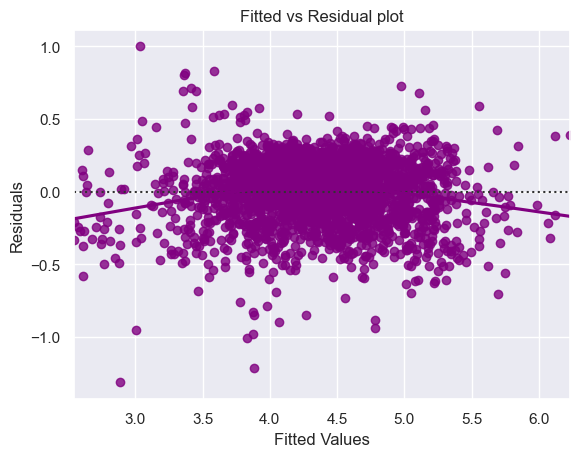

```python
# let's plot the fitted values vs residuals

sns.residplot(
    data=df_pred, x="Fitted Values", y="Residuals", color="purple", lowess=True
)
plt.xlabel("Fitted Values")
plt.ylabel("Residuals")
plt.title("Fitted vs Residual plot")
plt.show()
```

### Observations

- We see no pattern in the plot above.
- Hence, the assumptions of linearity and independence are satisfied.

### TEST FOR NORMALITY

- We will test for normality by checking the distribution of residuals, by checking the Q-Q plot of residuals, and by using the Shapiro-Wilk test.
- If the residuals follow a normal distribution, they will make a straight line plot, otherwise not.
- If the p-value of the Shapiro-Wilk test is greater than 0.05, we can say the residuals are normally distributed.

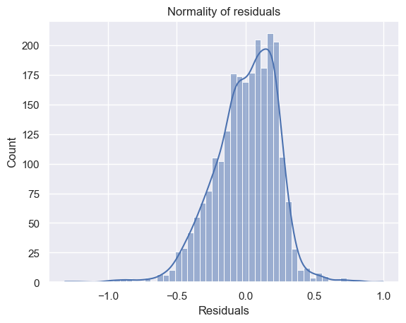

```python
sns.histplot(data=df_pred, x="Residuals", kde=True)
# Code to plot the distribution of residuals
plt.title("Normality of residuals")
plt.show()
```

### Observations

- The histogram of residuals does have a slight bell shape.
- Let's check the Q-Q plot.

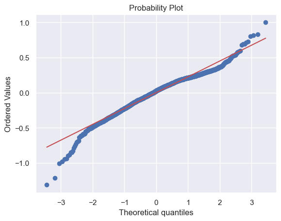

```python
import pylab
import scipy.stats as stats

stats.probplot(df_pred["Residuals"], dist="norm", plot=pylab)
# Code check Q-Q plot
plt.show()
```

### Observations

- The residuals more or less follow a straight line except for the tails.
- Let's check the results of the Shapiro-Wilk test.

```python
stats.shapiro(df_pred["Residuals"])
# Code to apply the Shapiro-Wilks test
```

```
ShapiroResult(statistic=0.9729294180870056, pvalue=5.525485308600747e-21)
```

### Observations

- Since p-value < 0.05, the residuals are not normal as per the Shapiro-Wilk test.
- Strictly speaking, the residuals are not normal. However, as an approximation, we can accept this distribution as close to being normal.
- So, the assumption is satisfied.

### TEST FOR HOMOSCEDASTICITY

- We will test for homoscedasticity by using the goldfeldquandt test.
- If we get a p-value greater than 0.05, we can say that the residuals are homoscedastic. Otherwise, they are heteroscedastic.

```python
import statsmodels.stats.api as sms
from statsmodels.compat import lzip

name = ["F statistic", "p-value"]
test = sms.het_goldfeldquandt(df_pred["Residuals"], x_train3)
# Code with the right train data to apply the Goldfeldquandt test
lzip(name, test)
```

```
[('F statistic', 1.0621029651017106), ('p-value', 0.1502301407106376)]
```

### Observations

- Since p-value > 0.05, the residuals are homoscedastic.
- So, the assumption is satisfied.

## Final Model Summary

```python
x_train_final = x_train3.copy()
x_test_final = x_test3.copy()
```

```python
olsmodel_final = sm.OLS(y_train, x_train_final).fit()
# Code to fit the final model
print(olsmodel_final.summary())
```

```
                              OLS Regression Results
=================================================================================
Dep. Variable:     normalized_used_price   R-squared:                       0.847
Model:                               OLS   Adj. R-squared:                  0.846
Method:                    Least Squares   F-statistic:                     509.9
Date:                   Thu, 19 Jun 2025   Prob (F-statistic):               0.00
Time:                           21:36:15   Log-Likelihood:                 142.48
No. Observations:                   2417   AIC:                            -231.0
Df Residuals:                       2390   BIC:                            -74.61
Df Model:                             26
Covariance Type:               nonrobust
========================================================================================
                           coef    std err          t      P>|t|      [0.025      0.975]
----------------------------------------------------------------------------------------
const                    1.7385      0.058     29.979      0.000       1.625       1.852
screen_size              0.0240      0.003      7.635      0.000       0.018       0.030
selfie_camera_mp         0.0140      0.001     13.088      0.000       0.012       0.016
int_memory               0.0001   6.77e-05      2.023      0.043    4.17e-06       0.000
ram                      0.0182      0.004      4.104      0.000       0.009       0.027
battery              -1.493e-05   7.05e-06     -2.118      0.034   -2.87e-05   -1.11e-06
weight                   0.0011      0.000      8.331      0.000       0.001       0.001
normalized_new_price     0.4031      0.011     35.417      0.000       0.381       0.425
years_since_release     -0.0157      0.004     -4.258      0.000      -0.023      -0.008
brand_name_Nokia         0.0909      0.031      2.938      0.003       0.030       0.152
brand_name_Samsung      -0.0356      0.016     -2.199      0.028      -0.067      -0.004
brand_name_Xiaomi        0.0690      0.025      2.718      0.007       0.019       0.119
4g_yes                   0.0495      0.015      3.291      0.001       0.020       0.079
main_camera_mp_8.0      -0.1172      0.014     -8.636      0.000      -0.144      -0.091
main_camera_mp_5.0      -0.1937      0.018    -11.056      0.000      -0.228      -0.159
main_camera_mp_3.15     -0.2646      0.030     -8.716      0.000      -0.324      -0.205
main_camera_mp_2.0      -0.2889      0.027    -10.711      0.000      -0.342      -0.236
main_camera_mp_16.0      0.1044      0.024      4.360      0.000       0.057       0.151
main_camera_mp_0.3      -0.4966      0.040    -12.287      0.000      -0.576      -0.417
main_camera_mp_48.0      0.2915      0.115      2.529      0.012       0.065       0.518
main_camera_mp_1.3      -0.5172      0.062     -8.331      0.000      -0.639      -0.395
main_camera_mp_0.08     -0.4826      0.231     -2.086      0.037      -0.936      -0.029
main_camera_mp_23.0      0.2392      0.067      3.581      0.000       0.108       0.370
main_camera_mp_4.0      -0.3089      0.094     -3.271      0.001      -0.494      -0.124
main_camera_mp_10.0     -0.2386      0.116     -2.060      0.040      -0.466      -0.011
main_camera_mp_6.7      -0.3082      0.120     -2.564      0.010      -0.544      -0.072
main_camera_mp_8.1      -0.2458      0.116     -2.113      0.035      -0.474      -0.018
==============================================================================
Omnibus:                      208.965   Durbin-Watson:                   1.911
Prob(Omnibus):                  0.000   Jarque-Bera (JB):              394.419
Skew:                          -0.586   Prob(JB):                     2.25e-86
Kurtosis:                       4.594   Cond. No.                     1.69e+05
==============================================================================

Notes:
[1] Standard Errors assume that the covariance matrix of the errors is correctly specified.
[2] The condition number is large, 1.69e+05. This might indicate that there are
strong multicollinearity or other numerical problems.
```

```python
# checking model performance on train set (seen 70% data)
print("Training Performance\n")
olsmodel_final_train_perf = model_performance_regression(
    olsmodel_final, x_train_final, y_train
)
# Code to check the performance on train data
olsmodel_final_train_perf
```

```
Training Performance
```

|  | RMSE | MAE | R-squared | Adj. R-squared | MAPE |
| --- | --- | --- | --- | --- | --- |
| 0 | 0.22812 | 0.179195 | 0.847258 | 0.845532 | 4.289722 |

```python
# checking model performance on test set (seen 30% data)
print("Test Performance\n")
olsmodel_final_test_perf = model_performance_regression(
    olsmodel_final, x_test_final, y_test
)
# Code to check performance on test data
olsmodel_final_test_perf
```

```
Test Performance
```

|  | RMSE | MAE | R-squared | Adj. R-squared | MAPE |
| --- | --- | --- | --- | --- | --- |
| 0 | 0.238456 | 0.184816 | 0.842349 | 0.83813 | 4.488782 |